# Risk Factor Analysis

## Outcome Variable

**Outcome Variable:** ever_swasted

## Predictor Variables

**Intervention Variable:** nchldlt5

**Adjustment Set:**

- arm
- W_mage
- meducyrs
- feducyrs
- hhwealth_quart
- hfoodsec
- W_mhtcm
- W_mwtkg
- W_mbmi
- W_nrooms
- W_parity
- impfloor
- impsan
- safeh20
- delta_W_mage
- delta_meducyrs
- delta_feducyrs
- delta_hhwealth_quart
- delta_hfoodsec
- delta_W_mhtcm
- delta_W_mwtkg
- delta_W_mbmi
- delta_W_nrooms
- delta_W_parity
- delta_impfloor
- delta_impsan
- delta_safeh20

## Stratifying Variables

The analysis was stratified on these variable(s):

- agecat
- studyid
- country

## Data Summary

| agecat | studyid | country | nchldlt5 | ever_swasted | n_cell | n |
| --- | --- | --- | --- | --- | --- | --- |
| 0-24 months | iLiNS-Zinc | BURKINA FASO | 1 | 0 | 1032 | 3189 |
| 0-24 months | iLiNS-Zinc | BURKINA FASO | 1 | 1 | 41 | 3189 |
| 0-24 months | iLiNS-Zinc | BURKINA FASO | 2+ | 0 | 2005 | 3189 |
| 0-24 months | iLiNS-Zinc | BURKINA FASO | 2+ | 1 | 111 | 3189 |
| 0-24 months | IRC | INDIA | 1 | 0 | 52 | 410 |
| 0-24 months | IRC | INDIA | 1 | 1 | 37 | 410 |
| 0-24 months | IRC | INDIA | 2+ | 0 | 218 | 410 |
| 0-24 months | IRC | INDIA | 2+ | 1 | 103 | 410 |
| 0-24 months | JiVitA-3 | BANGLADESH | 1 | 0 | 16167 | 26929 |
| 0-24 months | JiVitA-3 | BANGLADESH | 1 | 1 | 1057 | 26929 |
| 0-24 months | JiVitA-3 | BANGLADESH | 2+ | 0 | 9118 | 26929 |
| 0-24 months | JiVitA-3 | BANGLADESH | 2+ | 1 | 587 | 26929 |
| 0-24 months | LCNI-5 | MALAWI | 1 | 0 | 387 | 812 |
| 0-24 months | LCNI-5 | MALAWI | 1 | 1 | 4 | 812 |
| 0-24 months | LCNI-5 | MALAWI | 2+ | 0 | 417 | 812 |
| 0-24 months | LCNI-5 | MALAWI | 2+ | 1 | 4 | 812 |
| 0-24 months | NIH-Crypto | BANGLADESH | 1 | 0 | 491 | 758 |
| 0-24 months | NIH-Crypto | BANGLADESH | 1 | 1 | 50 | 758 |
| 0-24 months | NIH-Crypto | BANGLADESH | 2+ | 0 | 201 | 758 |
| 0-24 months | NIH-Crypto | BANGLADESH | 2+ | 1 | 16 | 758 |
| 0-24 months | PROVIDE | BANGLADESH | 1 | 0 | 481 | 700 |
| 0-24 months | PROVIDE | BANGLADESH | 1 | 1 | 31 | 700 |
| 0-24 months | PROVIDE | BANGLADESH | 2+ | 0 | 177 | 700 |
| 0-24 months | PROVIDE | BANGLADESH | 2+ | 1 | 11 | 700 |
| 0-24 months | TanzaniaChild2 | TANZANIA, UNITED REPUBLIC OF | 1 | 0 | 1525 | 2385 |
| 0-24 months | TanzaniaChild2 | TANZANIA, UNITED REPUBLIC OF | 1 | 1 | 112 | 2385 |
| 0-24 months | TanzaniaChild2 | TANZANIA, UNITED REPUBLIC OF | 2+ | 0 | 703 | 2385 |
| 0-24 months | TanzaniaChild2 | TANZANIA, UNITED REPUBLIC OF | 2+ | 1 | 45 | 2385 |

The following strata were considered:

- agecat: 0-24 months, studyid: iLiNS-Zinc, country: BURKINA FASO
- agecat: 0-24 months, studyid: IRC, country: INDIA
- agecat: 0-24 months, studyid: JiVitA-3, country: BANGLADESH
- agecat: 0-24 months, studyid: LCNI-5, country: MALAWI
- agecat: 0-24 months, studyid: NIH-Crypto, country: BANGLADESH
- agecat: 0-24 months, studyid: PROVIDE, country: BANGLADESH
- agecat: 0-24 months, studyid: TanzaniaChild2, country: TANZANIA, UNITED REPUBLIC OF

### Dropped Strata

Some strata were dropped due to rare outcomes:

- agecat: 0-24 months, studyid: LCNI-5, country: MALAWI

## Methods Detail

We're interested in the causal parameters $E[Y_a]$ for all values of $a \in \mathcal{A}$. These parameters represent the mean outcome if, possibly contrary to fact, we intervened to set all units to have $A=a$. Under the randomization and positivity assumptions, these are identified by the statistical parameters $\psi_a=E_W[E_{Y|A,W}(Y|A=a,W)]$. In addition, we're interested in the mean of $Y$, $E[Y]$ under no intervention (the observed mean). We will estimate these parameters by using SuperLearner to fit the relevant likelihood factors -- $E_{Y|A,W}(Y|A=a,W)$ and $p(A=a|W)$, and then updating our likelihood fit using a joint TMLE.

For unadjusted analyses ($W=\{\}$), initial likelihoods were estimated using Lrnr_glm to estimate the simple $E(Y|A)$ and Lrnr_mean to estimate $p(A)$. For adjusted analyses, a small library containing Lrnr_glmnet, Lrnr_xgboost, and Lrnr_mean was used.

Having estimated these parameters, we will then use the delta method to estimate relative risks and attributable risks relative to a prespecified baseline level of $A$.

# Results Detail

## Results Plots

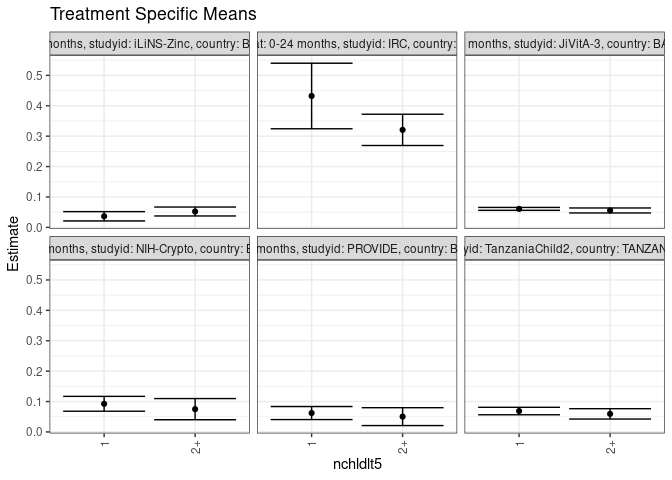

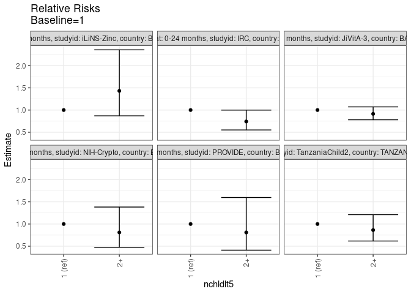

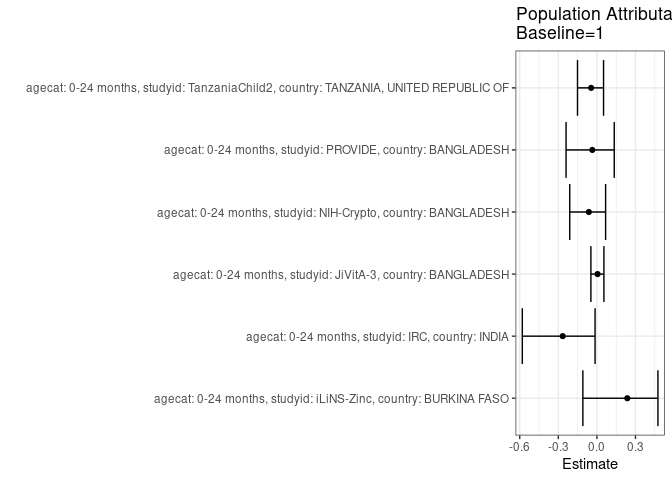

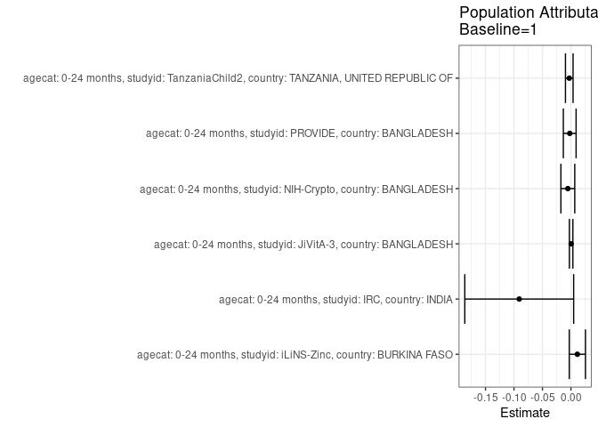

## Results Table

### Parameter: TSM

| agecat | studyid | country | intervention_level | baseline_level | estimate | ci_lower | ci_upper |
| --- | --- | --- | --- | --- | --- | --- | --- |
| 0-24 months | iLiNS-Zinc | BURKINA FASO | 1 | NA | 0.0363903 | 0.0211179 | 0.0516626 |
| 0-24 months | iLiNS-Zinc | BURKINA FASO | 2+ | NA | 0.0520942 | 0.0374197 | 0.0667687 |
| 0-24 months | IRC | INDIA | 1 | NA | 0.4322426 | 0.3243842 | 0.5401010 |
| 0-24 months | IRC | INDIA | 2+ | NA | 0.3207140 | 0.2692973 | 0.3721308 |
| 0-24 months | JiVitA-3 | BANGLADESH | 1 | NA | 0.0607287 | 0.0559799 | 0.0654776 |
| 0-24 months | JiVitA-3 | BANGLADESH | 2+ | NA | 0.0555144 | 0.0473267 | 0.0637021 |
| 0-24 months | NIH-Crypto | BANGLADESH | 1 | NA | 0.0925213 | 0.0680906 | 0.1169521 |
| 0-24 months | NIH-Crypto | BANGLADESH | 2+ | NA | 0.0749532 | 0.0401205 | 0.1097860 |
| 0-24 months | PROVIDE | BANGLADESH | 1 | NA | 0.0621390 | 0.0407140 | 0.0835640 |
| 0-24 months | PROVIDE | BANGLADESH | 2+ | NA | 0.0503216 | 0.0209018 | 0.0797414 |
| 0-24 months | TanzaniaChild2 | TANZANIA, UNITED REPUBLIC OF | 1 | NA | 0.0687655 | 0.0564572 | 0.0810737 |
| 0-24 months | TanzaniaChild2 | TANZANIA, UNITED REPUBLIC OF | 2+ | NA | 0.0594044 | 0.0423903 | 0.0764186 |

### Parameter: E(Y)

| agecat | studyid | country | intervention_level | baseline_level | estimate | ci_lower | ci_upper |
| --- | --- | --- | --- | --- | --- | --- | --- |
| 0-24 months | iLiNS-Zinc | BURKINA FASO | NA | NA | 0.0476638 | 0.0358801 | 0.0594476 |
| 0-24 months | IRC | INDIA | NA | NA | 0.3414634 | 0.2955068 | 0.3874201 |
| 0-24 months | JiVitA-3 | BANGLADESH | NA | NA | 0.0610494 | 0.0575683 | 0.0645305 |
| 0-24 months | NIH-Crypto | BANGLADESH | NA | NA | 0.0870712 | 0.0669870 | 0.1071555 |
| 0-24 months | PROVIDE | BANGLADESH | NA | NA | 0.0600000 | 0.0423945 | 0.0776055 |
| 0-24 months | TanzaniaChild2 | TANZANIA, UNITED REPUBLIC OF | NA | NA | 0.0658281 | 0.0558737 | 0.0757825 |

### Parameter: RR

| agecat | studyid | country | intervention_level | baseline_level | estimate | ci_lower | ci_upper |
| --- | --- | --- | --- | --- | --- | --- | --- |
| 0-24 months | iLiNS-Zinc | BURKINA FASO | 1 | 1 | 1.0000000 | 1.0000000 | 1.000000 |
| 0-24 months | iLiNS-Zinc | BURKINA FASO | 2+ | 1 | 1.4315412 | 0.8694551 | 2.357005 |
| 0-24 months | IRC | INDIA | 1 | 1 | 1.0000000 | 1.0000000 | 1.000000 |
| 0-24 months | IRC | INDIA | 2+ | 1 | 0.7419770 | 0.5512901 | 0.998621 |
| 0-24 months | JiVitA-3 | BANGLADESH | 1 | 1 | 1.0000000 | 1.0000000 | 1.000000 |
| 0-24 months | JiVitA-3 | BANGLADESH | 2+ | 1 | 0.9141375 | 0.7801773 | 1.071099 |
| 0-24 months | NIH-Crypto | BANGLADESH | 1 | 1 | 1.0000000 | 1.0000000 | 1.000000 |
| 0-24 months | NIH-Crypto | BANGLADESH | 2+ | 1 | 0.8101184 | 0.4747231 | 1.382473 |
| 0-24 months | PROVIDE | BANGLADESH | 1 | 1 | 1.0000000 | 1.0000000 | 1.000000 |
| 0-24 months | PROVIDE | BANGLADESH | 2+ | 1 | 0.8098230 | 0.4107083 | 1.596786 |
| 0-24 months | TanzaniaChild2 | TANZANIA, UNITED REPUBLIC OF | 1 | 1 | 1.0000000 | 1.0000000 | 1.000000 |
| 0-24 months | TanzaniaChild2 | TANZANIA, UNITED REPUBLIC OF | 2+ | 1 | 0.8638701 | 0.6164296 | 1.210635 |

### Parameter: PAR

| agecat | studyid | country | intervention_level | baseline_level | estimate | ci_lower | ci_upper |
| --- | --- | --- | --- | --- | --- | --- | --- |
| 0-24 months | iLiNS-Zinc | BURKINA FASO | 1 | NA | 0.0112736 | -0.0029576 | 0.0255048 |
| 0-24 months | IRC | INDIA | 1 | NA | -0.0907792 | -0.1863337 | 0.0047754 |
| 0-24 months | JiVitA-3 | BANGLADESH | 1 | NA | 0.0003207 | -0.0027629 | 0.0034043 |
| 0-24 months | NIH-Crypto | BANGLADESH | 1 | NA | -0.0054501 | -0.0176141 | 0.0067139 |
| 0-24 months | PROVIDE | BANGLADESH | 1 | NA | -0.0021390 | -0.0133350 | 0.0090570 |
| 0-24 months | TanzaniaChild2 | TANZANIA, UNITED REPUBLIC OF | 1 | NA | -0.0029374 | -0.0096042 | 0.0037295 |

### Parameter: PAF

| agecat | studyid | country | intervention_level | baseline_level | estimate | ci_lower | ci_upper |
| --- | --- | --- | --- | --- | --- | --- | --- |
| 0-24 months | iLiNS-Zinc | BURKINA FASO | 1 | NA | 0.2365223 | -0.1091681 | 0.4744726 |
| 0-24 months | IRC | INDIA | 1 | NA | -0.2658533 | -0.5799012 | -0.0142308 |
| 0-24 months | JiVitA-3 | BANGLADESH | 1 | NA | 0.0052529 | -0.0465759 | 0.0545149 |
| 0-24 months | NIH-Crypto | BANGLADESH | 1 | NA | -0.0625936 | -0.2112101 | 0.0677875 |
| 0-24 months | PROVIDE | BANGLADESH | 1 | NA | -0.0356500 | -0.2397137 | 0.1348238 |
| 0-24 months | TanzaniaChild2 | TANZANIA, UNITED REPUBLIC OF | 1 | NA | -0.0446218 | -0.1507724 | 0.0517371 |